# Serie_Temporal_SARIMAX-REGIOES-SIM-EntregaFinal

## PREVENDO O CONSUMO DE ENERGIA USANDO O MODELO SARIMAX

Neste notebook, apresentamos a predição dos valores de consumo por região e ao nível nacional, usando o modelo SARIMAX, que permite a adição de variáveis exógenas (temperatura/precipitação) à série temporal de consumo. De acordo com estudos de correlação que fizemos, essas variáveis são as que melhor explicam os padrões de consumo de energia.

O notebook está dividido da seguinte forma:

- Importação das bibliotecas
- Amostra das bases
- Plots das séries de consumo (por região)
- Verificações de estacionariedade (testes de Augmented Dickey-Fuller)
- Plots de autocorrelação das séries (por região)
- Plots de autocorrelação parciais (por região)
- Treinamento dos modelos e resultados por região
  - Região SECO
  - Região S
  - Região N
  - Região NE
- Resultados em nível nacional

### Importando as bibliotecas

```python
import pandas as pd
import numpy as np
import matplotlib.pyplot as plt
%matplotlib inline
plt.rc("figure", figsize=(16,8))

import matplotlib.dates as mdates
from statsmodels.graphics.tsaplots import plot_acf
from statsmodels.graphics.tsaplots import plot_pacf
from statsmodels.tsa.seasonal import seasonal_decompose
from statsmodels.tsa.arima_model import ARIMA
from statsmodels.tsa.arima_model import ARIMAResults
import statsmodels.api as qqplot
import scipy.stats as stats

import warnings
warnings.filterwarnings('ignore')
```

```python
import os, sys, pyodbc
import pandas.io.sql as psql

pyodbc.autocommit = True
con = pyodbc.connect("DSN=HiveDSN", autocommit=True)

cursor = con.cursor()
sql_consumo = "SELECT * from equipe.bd_consumo_data_float_por_dia"
sql_seco = "SELECT * from equipe.bd_estacoes_regiao_seco_minmax_por_dia"
sql_s = "SELECT * from equipe.bd_estacoes_regiao_s_minmax_por_dia"
sql_n = "SELECT * from equipe.bd_estacoes_regiao_n_minmax_por_dia"
sql_ne = "SELECT * from equipe.bd_estacoes_regiao_ne_minmax_por_dia"

# data frames
df_cons = psql.read_sql(sql_consumo, con)
df_tseco = psql.read_sql(sql_seco, con)
df_ts = psql.read_sql(sql_s, con)
df_tn = psql.read_sql(sql_n, con)
df_tne = psql.read_sql(sql_ne, con)

df_cons = df_cons.set_index('datacompleta')
df_tseco = df_tseco.set_index('datacompleta')
df_ts = df_ts.set_index('datacompleta')
df_tn = df_tn.set_index('datacompleta')
df_tne = df_tne.set_index('datacompleta')
```

### Amostra das bases

```python
df_cons.head()
```

| datacompleta | seco | s | ne | n | sin |
| --- | --- | --- | --- | --- | --- |
| 2013-01-01 | 29850.0 | 6552.0 | 7583.0 | 3564.0 | 47549.0 |
| 2013-01-02 | 36604.0 | 8364.0 | 8979.0 | 3806.0 | 57753.0 |
| 2013-01-03 | 37330.0 | 9471.0 | 9428.0 | 3903.0 | 60132.0 |
| 2013-01-04 | 37248.0 | 10107.0 | 9406.0 | 3931.0 | 60693.0 |
| 2013-01-05 | 35165.0 | 9369.0 | 8993.0 | 3843.0 | 57369.0 |

```python
df_tseco.head()
```

| datacompleta | precmax | tempmax | tempmin | umidmax | umidmin |
| --- | --- | --- | --- | --- | --- |
| 2013-01-01 | 23.400000 | 33.700001 | 18.100000 | 96.0 | 27.0 |
| 2013-01-02 | 9.600000 | 34.400002 | 18.000000 | 96.0 | 24.0 |
| 2013-01-03 | 12.000000 | 34.700001 | 17.100000 | 96.0 | 22.0 |
| 2013-01-04 | 17.799999 | 33.299999 | 17.700001 | 96.0 | 32.0 |
| 2013-01-05 | 25.600000 | 33.900002 | 19.000000 | 96.0 | 24.0 |

### Plots das séries de consumo

```python
# Separando os dataframes para cada região
df_seco  = df_cons[["seco"]].copy()
df_s     = df_cons[["s"]].copy()
df_nes   = df_cons[["ne"]].copy()
df_n     = df_cons[["n"]].copy()
```

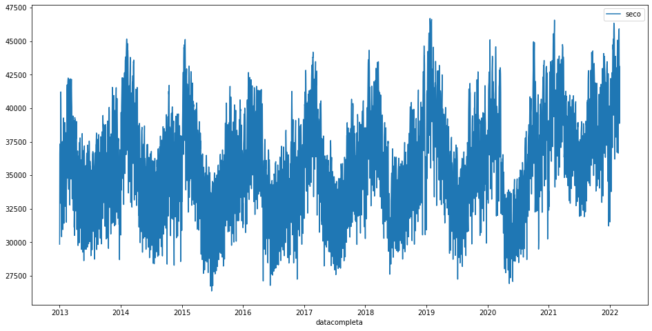

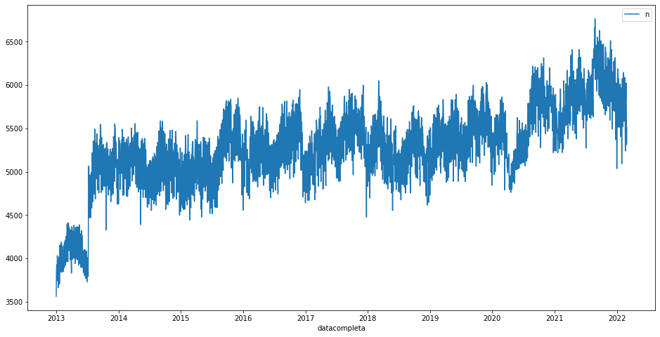

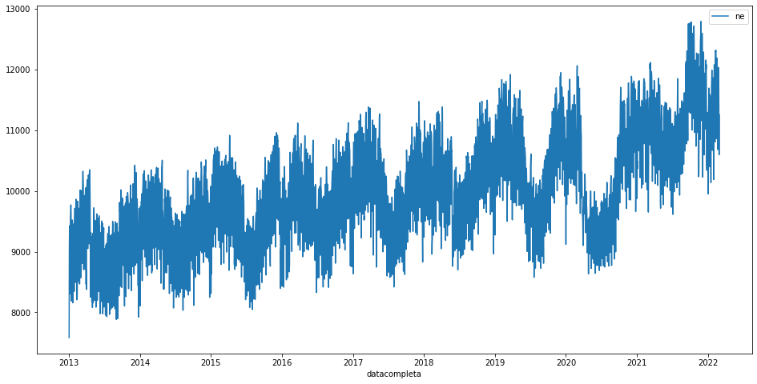

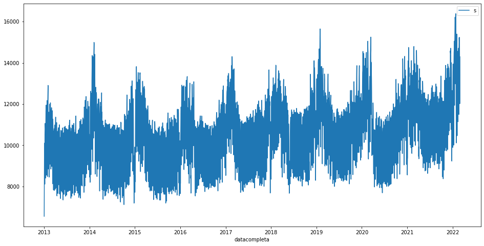

```python
fig = plt.gcf()


df_seco[["seco"]].plot()
df_n[["n"]].plot()
df_nes[["ne"]].plot()
df_s[["s"]].plot()

plt.show()
```

### Verificando a estacionariedade das séries

```python
#código auxiliar para a verificação da estacionaridade (teste Augmented Dickey-Fuller)
from statsmodels.tsa.stattools import adfuller

def adf_test(series,title=''):
    """
    Pass in a time series and an optional title, returns an ADF report
    """
    print(f'Augmented Dickey-Fuller Test: {title}')
    result = adfuller(series.dropna(),autolag='AIC') # .dropna() handles differenced data

    labels = ['ADF test statistic','p-value','# lags used','# observations']
    out = pd.Series(result[0:4],index=labels)

    for key,val in result[4].items():
        out[f'critical value ({key})']=val

    print(out.to_string())          # .to_string() removes the line "dtype: float64"

    if result[1] <= 0.05:
        print("Strong evidence against the null hypothesis")
        print("Reject the null hypothesis")
        print("Data has no unit root and is stationary")
    else:
        print("Weak evidence against the null hypothesis")
        print("Fail to reject the null hypothesis")
        print("Data has a unit root and is non-stationary")
```

```python
adf_test(df_seco["seco"])
```

```
Augmented Dickey-Fuller Test:
ADF test statistic        -4.492121
p-value                    0.000203
# lags used               28.000000
# observations          3317.000000
critical value (1%)       -3.432323
critical value (5%)       -2.862412
critical value (10%)      -2.567234
Strong evidence against the null hypothesis
Reject the null hypothesis
Data has no unit root and is stationary
```

```python
adf_test(df_s["s"])
```

```
Augmented Dickey-Fuller Test:
ADF test statistic        -3.805170
p-value                    0.002855
# lags used               29.000000
# observations          3316.000000
critical value (1%)       -3.432324
critical value (5%)       -2.862412
critical value (10%)      -2.567234
Strong evidence against the null hypothesis
Reject the null hypothesis
Data has no unit root and is stationary
```

```python
adf_test(df_n["n"])
```

```
Augmented Dickey-Fuller Test:
ADF test statistic        -3.479146
p-value                    0.008539
# lags used               28.000000
# observations          3317.000000
critical value (1%)       -3.432323
critical value (5%)       -2.862412
critical value (10%)      -2.567234
Strong evidence against the null hypothesis
Reject the null hypothesis
Data has no unit root and is stationary
```

```python
adf_test(df_nes["ne"])
```

```
Augmented Dickey-Fuller Test:
ADF test statistic        -2.630222
p-value                    0.086910
# lags used               28.000000
# observations          3317.000000
critical value (1%)       -3.432323
critical value (5%)       -2.862412
critical value (10%)      -2.567234
Weak evidence against the null hypothesis
Fail to reject the null hypothesis
Data has a unit root and is non-stationary
```

```python
#Transformando a serie NE em estacionária pela diferencá

#df_nes_dif = df_nes.diff().dropna()

#adf_test(df_nes_dif["ne"])
```

### Auto-correlações

#### Região SECO

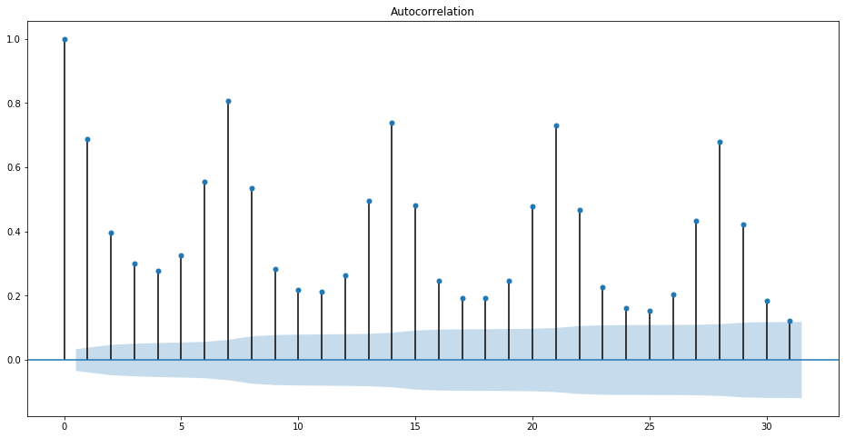

```python
from statsmodels.graphics.tsaplots import plot_acf
x=plot_acf(df_seco["seco"], lags=31)
```

#### Região S

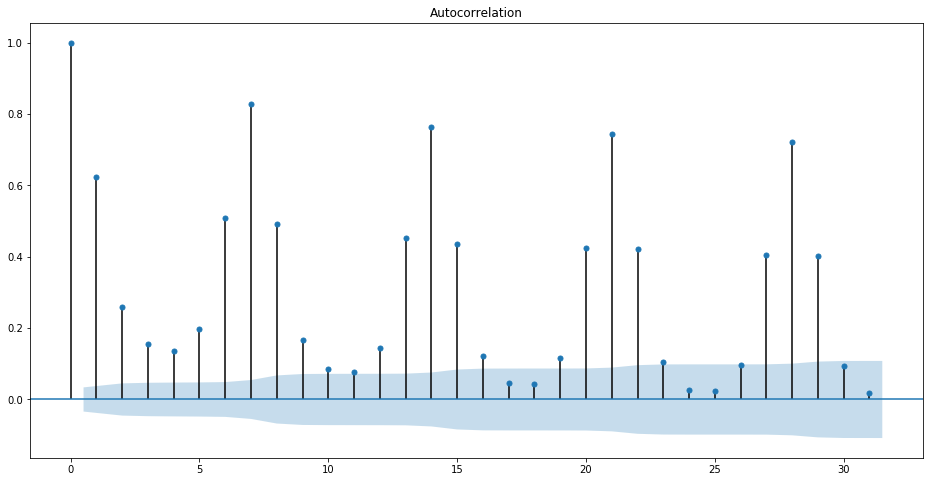

```python
from statsmodels.graphics.tsaplots import plot_acf
x=plot_acf(df_s["s"], lags=31)
```

#### Região N

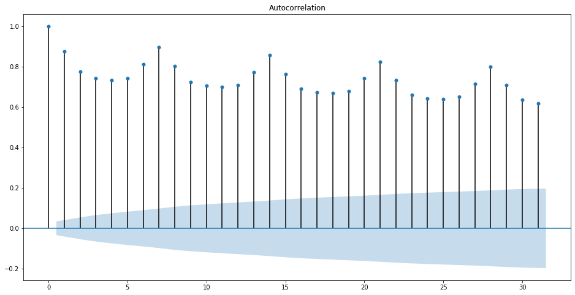

```python
from statsmodels.graphics.tsaplots import plot_acf
x=plot_acf(df_n["n"], lags=31)
```

#### Região NE

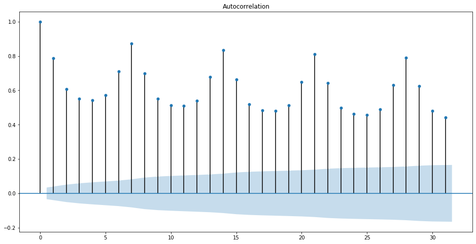

```python
from statsmodels.graphics.tsaplots import plot_acf
x=plot_acf(df_nes["ne"], lags=31)
```

### Auto-correlações Parciais

#### Região SECO

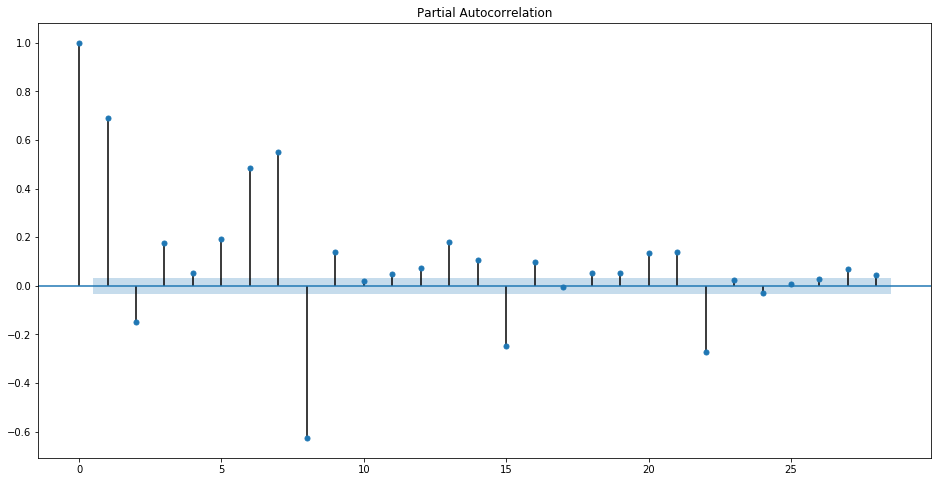

```python
from statsmodels.graphics.tsaplots import plot_pacf
x=plot_pacf(df_seco["seco"], lags=28)
```

[figure not shown]

```python
from statsmodels.graphics.tsaplots import plot_acf
x=plot_acf(df_s["s"], lags=31)
```

#### Região N

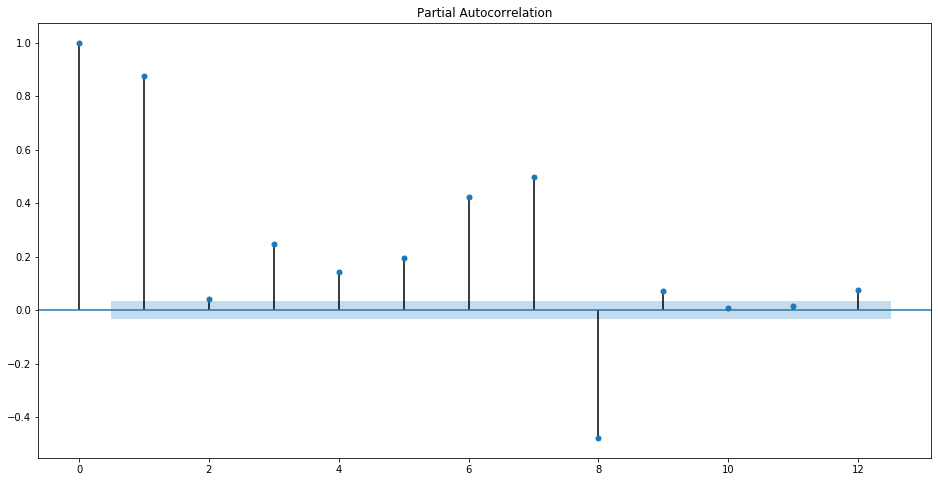

```python
# PACF
from statsmodels.graphics.tsaplots import plot_acf, plot_pacf

x=plot_pacf(df_n["n"], lags=12)
```

#### Região NE

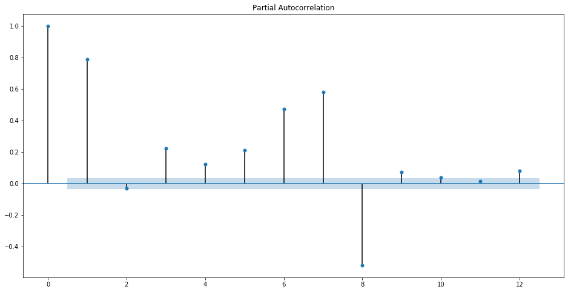

```python
# PACF
from statsmodels.graphics.tsaplots import plot_acf, plot_pacf

x=plot_pacf(df_nes["ne"], lags=12)
```

##### Os plots de auto-correlação acima nos indicam parâmetros múltiplos de 7 para a criação do modelo SARIMAX.

#### Um plot interessante... que mostra o padrão anual de consumo de energia.

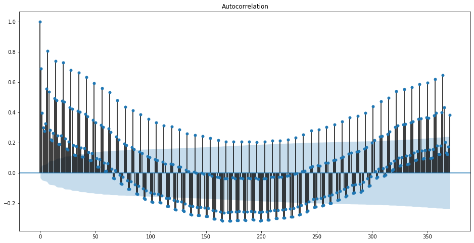

```python
x=plot_acf(df_seco["seco"], lags=370)
```